# week 4

Keith Bailey

March 4, 2018

## Purpose

The purpose of this exercise is to attempt to create a categorisation algorithm to be able to predict, based on specific regressors, what the dependent variable, classe will be. Thie will help us determine the quality of a users exercise is and thus help the user improve or at least know how their workout is going/went.

Lets start by fetching the data and some quick inspection

```r
training_initial <- read.csv("https://d396qusza40orc.cloudfront.net/predmachlearn/pml-training.csv")
testing_initial <- read.csv("https://d396qusza40orc.cloudfront.net/predmachlearn/pml-testing.csv")
dim(training_initial)
```

```
## [1] 19622   160
```

## Cleanup, cleanup, always a bloody cleanup

As ever the data we have is not perfect. A quick inspection shows a lot of columns with NA, but no column is completely made of NA.

```r
head(training_initial)
```

```
##   X user_name raw_timestamp_part_1 raw_timestamp_part_2   cvtd_timestamp
## 1 1  carlitos           1323084231               788290 05/12/2011 11:23
## 2 2  carlitos           1323084231               808298 05/12/2011 11:23
## 3 3  carlitos           1323084231               820366 05/12/2011 11:23
## 4 4  carlitos           1323084232               120339 05/12/2011 11:23
## 5 5  carlitos           1323084232               196328 05/12/2011 11:23
## 6 6  carlitos           1323084232               304277 05/12/2011 11:23
##   new_window num_window roll_belt pitch_belt yaw_belt total_accel_belt
## 1         no         11      1.41       8.07    -94.4                3
## 2         no         11      1.41       8.07    -94.4                3
## 3         no         11      1.42       8.07    -94.4                3
## 4         no         12      1.48       8.05    -94.4                3
## 5         no         12      1.48       8.07    -94.4                3
## 6         no         12      1.45       8.06    -94.4                3
##   kurtosis_roll_belt kurtosis_picth_belt kurtosis_yaw_belt
```

[output cut: 265 more lines]

We can see that the the most NAs a single column has is 19,216.

```r
max(colSums(is.na(training_initial)))
```

```
## [1] 19216
```

In fact, either a column has 0 NAs or 19,216. Therefore we are going to remove all columns with NAs present. But to continue the cleanup, we are also going to remove all blank records too.

```r
training_initial <- training_initial[,colSums(is.na(training_initial))<19216]
training_initial <- training_initial[,colSums(training_initial=="")<19216]
```

This has reduced our number of predictors down from 160 to 60.

A number of the variables in the data are not useful for categorical learning, such as time, window & X(the index)

```r
training <- training_initial[,-c(1:7)]
```

Lets now split out training set into two, so we can see how well our model building does before we apply it to our test data

```r
set.seed(123)
inTrain_split <- createDataPartition(training$classe, p=0.7, list = FALSE)

split_training <- training[inTrain_split, ]
split_validation <- training[-inTrain_split, ]
```

## Model Building

### Random Forest

Although we could lead here with a normal categorization tree and investigate pruning, using a random forest eliminates the need for this, even if you do need to get a coffee once you start it.

To improve speed, we are going to use the randomForest package rather than caret.

```r
modRF <- randomForest::randomForest(classe~ ., data=split_training, importance=TRUE,
                           proximity=TRUE)

print(modRF)
```

```
##
## Call:
##  randomForest(formula = classe ~ ., data = split_training, importance = TRUE,      proximity = TRUE)
##                Type of random forest: classification
##                      Number of trees: 500
## No. of variables tried at each split: 7
##
##         OOB estimate of  error rate: 0.54%
## Confusion matrix:
##      A    B    C    D    E  class.error
## A 3904    1    0    0    1 0.0005120328
## B   11 2640    7    0    0 0.0067720090
## C    1   16 2376    3    0 0.0083472454
## D    0    0   24 2227    1 0.0111012433
## E    0    0    3    6 2516 0.0035643564
```

The random forest method only has an out of bag error rate of 0.54%, which leads me to believe this is a very effective. Let us now apply this to our validation set. If it is still very effective, we will move onto our prediction.

### Validation Test

Let us predict the validation values and compare to a confusion matrix and comparison plot.

```r
predVal <- predict(modRF, newdata = split_validation)

confusionMatrix(predVal, split_validation$class)
```

```
## Confusion Matrix and Statistics
##
##           Reference
## Prediction    A    B    C    D    E
##          A 1673    5    0    0    0
##          B    1 1133   12    0    0
##          C    0    1 1014   12    0
##          D    0    0    0  951    0
##          E    0    0    0    1 1082
##
## Overall Statistics
##
##                Accuracy : 0.9946
##                  95% CI : (0.9923, 0.9963)
##     No Information Rate : 0.2845
##     P-Value [Acc > NIR] : < 2.2e-16
##
##                   Kappa : 0.9931
##  Mcnemar's Test P-Value : NA
##
## Statistics by Class:
##
##                      Class: A Class: B Class: C Class: D Class: E
## Sensitivity            0.9994   0.9947   0.9883   0.9865   1.0000
## Specificity            0.9988   0.9973   0.9973   1.0000   0.9998
## Pos Pred Value         0.9970   0.9887   0.9873   1.0000   0.9991
## Neg Pred Value         0.9998   0.9987   0.9975   0.9974   1.0000
## Prevalence             0.2845   0.1935   0.1743   0.1638   0.1839
## Detection Rate         0.2843   0.1925   0.1723   0.1616   0.1839
## Detection Prevalence   0.2851   0.1947   0.1745   0.1616   0.1840
## Balanced Accuracy      0.9991   0.9960   0.9928   0.9933   0.9999
```

From this we can see the random forest has an accuracy rate of 99.46% in the validation set/out of sample error rate of (1-0.9946 = 0.54%), which is incredibly good and not something you would expect in the wild. It is probably related to just how much data has been collected and how many regressors the dataset has.

Lets inspect the data in the form of charts as well to see what the data looks like

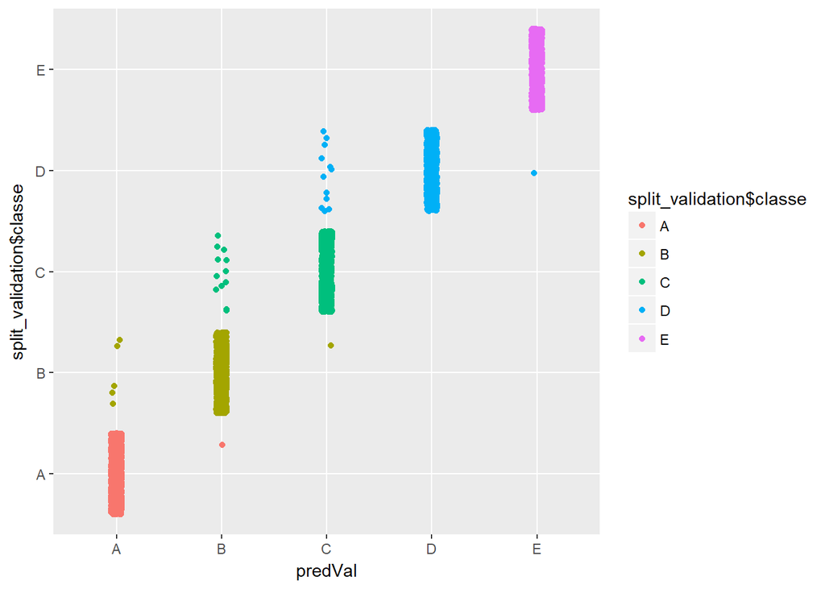

```r
require(ggplot2)

  ggplot() + geom_jitter(aes(predVal, split_validation$classe, colour = split_validation$classe),
              position = position_jitter(width = 0.05))
```

## Apply Our Model

Now we have a lot of confidence in our model, let us apply it to the test set

```r
predict(modRF, newdata = testing_initial)
```

```
##  1  2  3  4  5  6  7  8  9 10 11 12 13 14 15 16 17 18 19 20
##  B  A  B  A  A  E  D  B  A  A  B  C  B  A  E  E  A  B  B  B
## Levels: A B C D E
```